# LAB1

## Lab Experiment – 1 Pulse-Width-Modulation (PWM) and Filter Characteristics

All labs from here :https://cusp.umn.edu/power-electronics/introduction-power-electronics

**1.**

[figure not shown]

**2.** $$ \bar{V_a} = V_o $$

**3.**

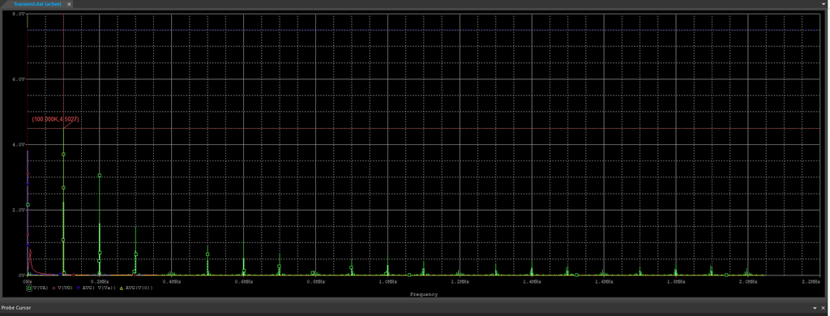

The -LC resonace frequency of an ideal L-C filter is $\frac{1}{\sqrt{LC}}$ . The NON ideal filter resosnce filter is as follows -see [FREQUENCY RESPONSE AND FILTERING](http://cas.ee.ic.ac.uk/people/dhaigh/EE1.1%20Files/Notes/7%20Frequency%20response%20and%20filtering.pdf):

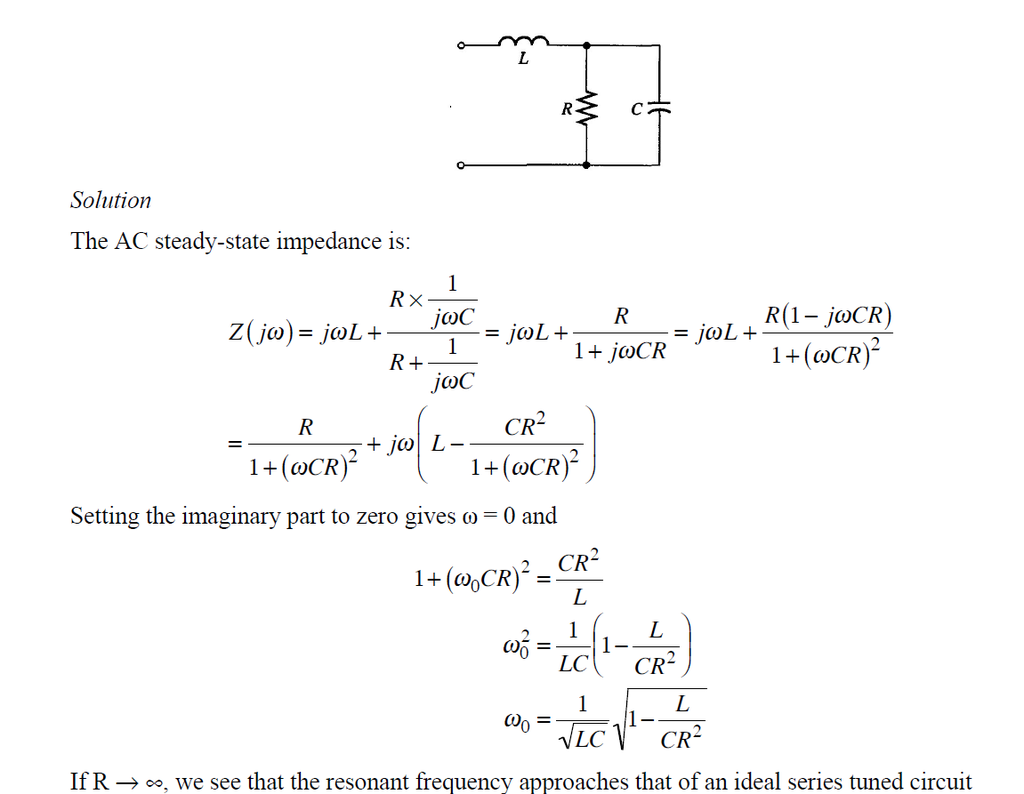

In our case $\omega_0=40e3==>f_0=6.36KHz << 100KHz$. In order to measure the attanuation I added another schematic for AC analys and sketching a Bode plot , see https://training.ti.com/pspice-ti-ac-sweep-analysis?context=1146489-1146488-1146480

[figure not shown]

[figure not shown]

The attenuation@ 100KHz is -45dB

**4.** For $6\mu s$ we have

[figure not shown]

[figure not shown]

Of course all the answers stays as before we did not change the circuit so the resosnace frequency, the frequency respinse and the attenuation remain the same

**5.** For 20KHZ:fundamental frequency is 20KHz as expected

[figure not shown]

[figure not shown]

**6**. Calculation of the Fourier transform from [FREQUENCY RESPONSE AND FILTERING](http://cas.ee.ic.ac.uk/people/dhaigh/EE1.1%20Files/Notes/7%20Frequency%20response%20and%20filtering.pdf):

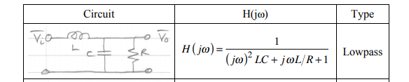

So if $$H(\omega) =\frac{1}{(j\omega)^2LC+j\omega L/R+1}$$

at $f=100KHz$ $|H(\omega)|$= -45.866dB =

```python
# importing "cmath" for complex number operations
#calculating the frequency response at 100KHz
#########################################################
import cmath
import math
omega = 2*math.pi*100e3
L=5e-6
C=100e-6
R=0.5
H=abs(1/(((1j*omega)**2)*L*C+1j*omega*L/R+1))
print ("H =",H)
print ("H =",20*math.log10(H),"dB")
```

```
H = 0.005089250918545767
H = -45.86692272608522 dB
```

[figure not shown]

The result does fit the simulation

[figure not shown]

```python
# importing "cmath" for complex number operations
#calculating the resonant frequency
#########################################################
import cmath
import math
L=5e-6
C=100e-6
R=0.5
omega0 = 1/math.sqrt(L*C)*math.sqrt(1-L/(C*R**2))
f0 = 1/(2*math.pi)*omega0
print ("f0 = %1.4e %s " %(f0,'Hz'))
```

```
f0 = 6.3662e+03 Hz
```

**.8** I do not understand the difference here.